# McKinsey Sales Hackathon Jan 2018

Bala Kesavan

22 January 2018

# McKinsey Sales Excellence Hackathon

The business problem is to predict loan approval, given applicant details like income, debt and demographics.

## Exploratory Data Analysis

We start with EDA and list down some of the key observations made, while the basis for the same is displayed in the calls below.  
###Key observations  
‘Approved’ is continuous. Change to categorical.  
Too many ‘NA’ in ‘EMI’, ‘Interest_Rate’, ‘Loan_Period’, ‘Loan_Amount’. Omit columns?  
51 NA in ‘Existing_EMI’. Omit rows?  
Unlabelled levels in ‘Primary_Bank_Type’. Add name?  
Unlabelled levels in ‘Employer_Category1’, ‘Employer_Code’, ‘City_Category’. Add name? Make categorical.  
Skewed distributions for ‘Existing_EMI’ and ‘Monthly_Income’. Transform - bin/ bound/ log etc.  
Change DOB to Age. 15 rows without DOB. Delete rows?  
Too many levels for ‘City_Code’, ‘Employer_Code’, ‘Customer_Existing_Primary_Bank_Code’. Drop?  
The raw ‘Monthly Income’ and ‘Existing EMI’ variables are not showing sufficient discerning power.  
The DOB variable in its current categorical form is unusable.  
The remaining variables are categorical. Further EDA is performed after data processing to address above issues.

```r
summary(trainData)
```

```
##                ID           Gender            DOB
##  APPA10000905029:    1   Female:29764   11/01/82:  253
##  APPA10001412205:    1   Male  :39949   04/03/71:  183
##  APPA10004965619:    1                  03/03/71:  121
##  APPA10007179048:    1                  03/03/91:  103
##  APPA10007532038:    1                  03/03/81:   88
##  APPA10009948043:    1                  03/03/87:   83
##  (Other)        :69707                  (Other) :68882
##  Lead_Creation_Date   City_Code     City_Category    Employer_Code
##  02/09/16: 1838     C10001 :10007    :  814                 : 4018
##  22/09/16: 1629     C10002 : 8716   A:49885       COM0000002:  457
##  29/09/16: 1038     C10003 : 8666   B: 7320       COM0000003:  324
##  26/09/16: 1036     C10004 : 5843   C:11694       COM0000004:  262
##  30/09/16: 1028     C10005 : 5564                 COM0000005:  243
##  28/09/16: 1001     C10006 : 4203                 COM0000006:  195
##  (Other) :62143     (Other):26714                 (Other)   :64214
##  Employer_Category1 Employer_Category2 Monthly_Income
##   : 4018            Min.   :1.00       Min.   :       0
##  A:33336            1st Qu.:4.00       1st Qu.:    1650
##  B:18056            Median :4.00       Median :    2500
##  C:14303            Mean   :3.72       Mean   :    5622
##                     3rd Qu.:4.00       3rd Qu.:    4000
##                     Max.   :4.00       Max.   :38383838
##                     NA's   :4298
##  Customer_Existing_Primary_Bank_Code Primary_Bank_Type Contacted
##  B001   :14197                        : 9391           N:24438
##  B002   :10880                       G:20703           Y:45275
##  B003   : 9515                       P:39619
##         : 9391
##  B004   : 7070
##  B005   : 1920
##  (Other):16740
##      Source      Source_Category  Existing_EMI       Loan_Amount
##  S122   :30941   A:    3         Min.   :     0.0   Min.   :  5000
##  S133   :23877   B:29812         1st Qu.:     0.0   1st Qu.: 20000
##  S159   : 4474   C:11374         Median :     0.0   Median : 30000
##  S143   : 3480   D:  497         Mean   :   360.9   Mean   : 39430
##  S127   : 1546   E: 1050         3rd Qu.:   350.0   3rd Qu.: 50000
##  S137   : 1400   F:  459         Max.   :545436.5   Max.   :300000
##  (Other): 3995   G:26518         NA's   :51         NA's   :27709
##   Loan_Period    Interest_Rate        EMI             Var1
##  Min.   :1.000   Min.   :11.99   Min.   :  118   Min.   : 0.000
##  1st Qu.:3.000   1st Qu.:15.25   1st Qu.:  649   1st Qu.: 0.000
##  Median :4.000   Median :18.00   Median :  941   Median : 2.000
##  Mean   :3.891   Mean   :19.21   Mean   : 1101   Mean   : 3.948
##  3rd Qu.:5.000   3rd Qu.:20.00   3rd Qu.: 1295   3rd Qu.: 7.000
##  Max.   :6.000   Max.   :37.00   Max.   :13556   Max.   :10.000
##  NA's   :27709   NA's   :47437   NA's   :47437
##     Approved
##  Min.   :0.00000
##  1st Qu.:0.00000
##  Median :0.00000
##  Mean   :0.01463
##  3rd Qu.:0.00000
##  Max.   :1.00000
##
```

```r
str(trainData)
```

```
## 'data.frame':    69713 obs. of  22 variables:
##  $ ID                                 : Factor w/ 69713 levels "APPA10000905029",..: 7809 9062 12525 15528 17798 24053 28923 29974 33036 36522 ...
##  $ Gender                             : Factor w/ 2 levels "Female","Male": 1 2 2 2 2 1 2 1 2 1 ...
##  $ DOB                                : Factor w/ 10760 levels "","01/01/53",..: 8114 2595 3643 10258 6633 8267 9654 4343 860 4722 ...
##  $ Lead_Creation_Date                 : Factor w/ 92 levels "01/07/16","01/08/16",..: 43 10 55 25 58 1 4 7 4 4 ...
##  $ City_Code                          : Factor w/ 679 levels "","C10001","C10002",..: 2 4 126 478 3 403 23 4 4 15 ...
##  $ City_Category                      : Factor w/ 4 levels "","A","B","C": 2 2 4 4 2 4 3 2 2 3 ...
##  $ Employer_Code                      : Factor w/ 36618 levels "","COM0000002",..: 29286 2 5128 4081 1777 7346 21787 14047 9675 28240 ...
##  $ Employer_Category1                 : Factor w/ 4 levels "","A","B","C": 2 4 4 2 2 2 3 2 2 2 ...
##  $ Employer_Category2                 : int  4 1 4 4 4 4 4 4 4 4 ...
##  $ Monthly_Income                     : num  2000 3500 2250 3500 10000 7000 7500 3000 2500 2500 ...
##  $ Customer_Existing_Primary_Bank_Code: Factor w/ 58 levels "","B001","B002",..: 2 3 4 4 2 15 4 7 18 1 ...
##  $ Primary_Bank_Type                  : Factor w/ 3 levels "","G","P": 3 3 2 2 3 3 2 3 2 1 ...
##  $ Contacted                          : Factor w/ 2 levels "N","Y": 1 2 2 2 2 1 2 2 2 1 ...
##  $ Source                             : Factor w/ 29 levels "S122","S123",..: 1 1 16 16 8 7 1 7 7 1 ...
##  $ Source_Category                    : Factor w/ 7 levels "A","B","C","D",..: 7 7 2 2 2 2 3 2 2 2 ...
##  $ Existing_EMI                       : num  0 0 0 0 2500 0 0 0 0 0 ...
##  $ Loan_Amount                        : int  NA 20000 45000 92000 50000 NA 130000 30000 66000 NA ...
##  $ Loan_Period                        : int  NA 2 4 5 2 NA 5 3 5 NA ...
##  $ Interest_Rate                      : num  NA 13.2 NA NA NA ...
##  $ EMI                                : int  NA 953 NA NA NA NA 3082 1088 1749 NA ...
##  $ Var1                               : int  0 10 0 7 10 0 10 0 7 0 ...
##  $ Approved                           : int  0 0 0 0 0 0 0 0 0 0 ...
```

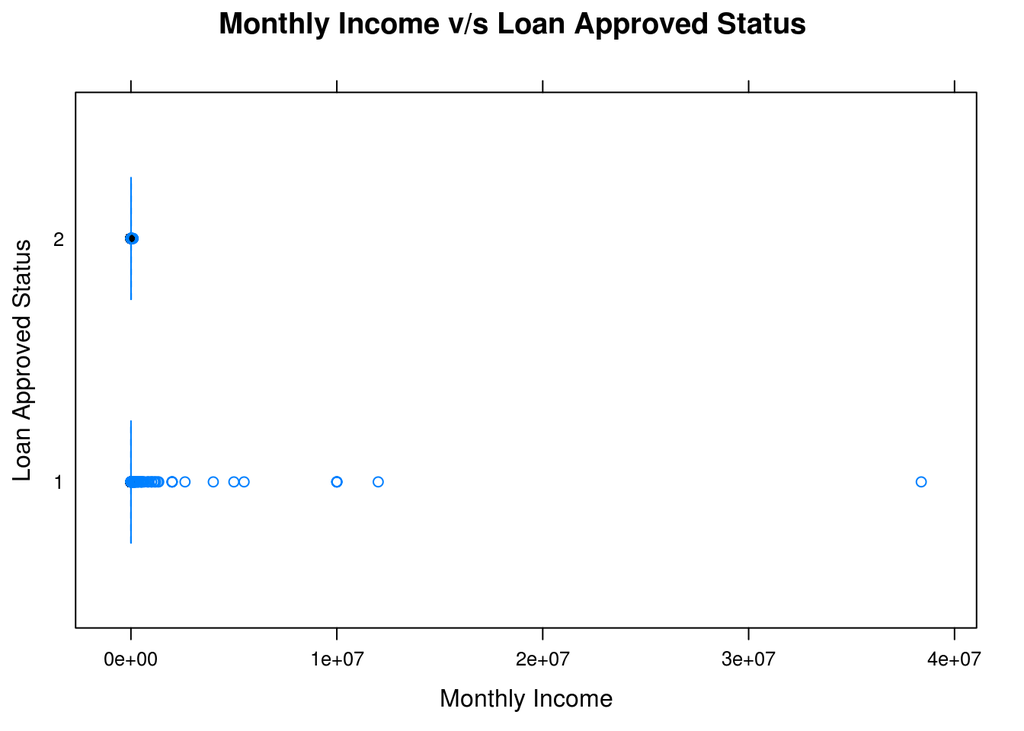

```r
bwplot(Approved~Monthly_Income, data = trainData, xlab = 'Monthly Income', ylab = 'Loan Approved Status', main = 'Monthly Income v/s Loan Approved Status')
```

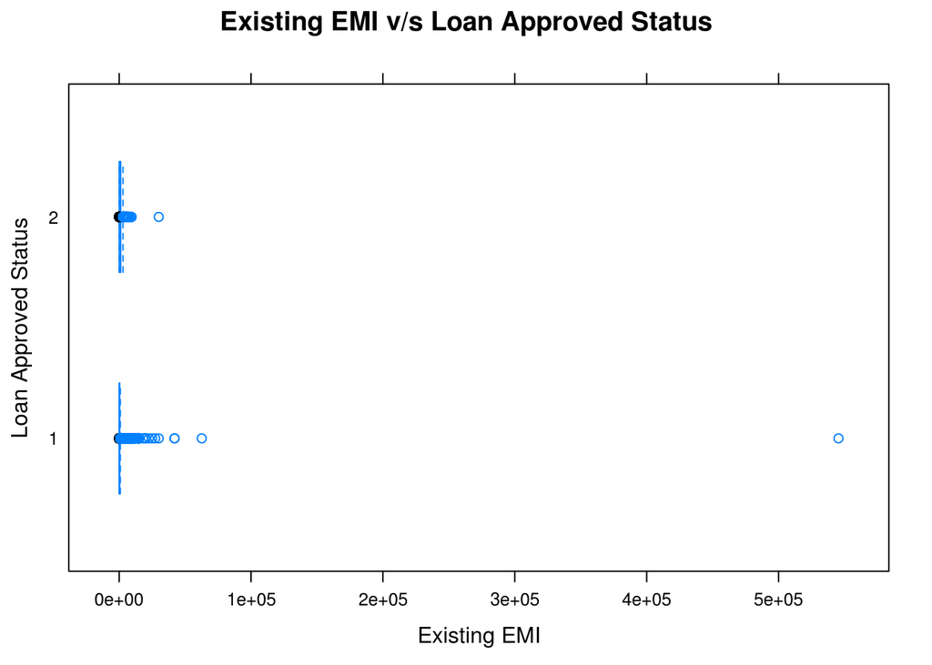

```r
bwplot(Approved~Existing_EMI, data = trainData, xlab = 'Existing EMI', ylab = 'Loan Approved Status', main = 'Existing EMI v/s Loan Approved Status')
```

## Data processing

Data processing/ munging has been done using external functions listed at the very end of this file.

```r
trainData_WIP <- McK_pre_proc_train_only(trainData)
trainData_WIP <- McK_pre_proc_common(trainData_WIP)

testData_WIP <- McK_pre_proc_test_only(testData)
testData_WIP <- McK_pre_proc_common(testData_WIP)
```

## EDA on processed data

The raw ‘Monthly Income’ and ‘Existing EMI’ variables were not showing sufficient discerning power. After transformation to log form, this has improved. The DOB variable in its current categorical form is unusable. But transformation into the applicant’s ‘Age’ shows potential. The remaining variables are categorical. Chi Square tests of independence between each variable and loan approval are conducted. Graphical tests are also provided to visualize the dependence. None of the variables analyzed can be excluded since the null hypothesis of independence have to be rejected due to the low p values.

```r
library(dplyr)
library(ggplot2)
#Bivariate analysis: Gender v/s Approved
chisq.test(trainData_WIP$Gender, trainData_WIP$Approved)
```

```
##
##  Pearson's Chi-squared test with Yates' continuity correction
##
## data:  trainData_WIP$Gender and trainData_WIP$Approved
## X-squared = 141.73, df = 1, p-value < 2.2e-16
```

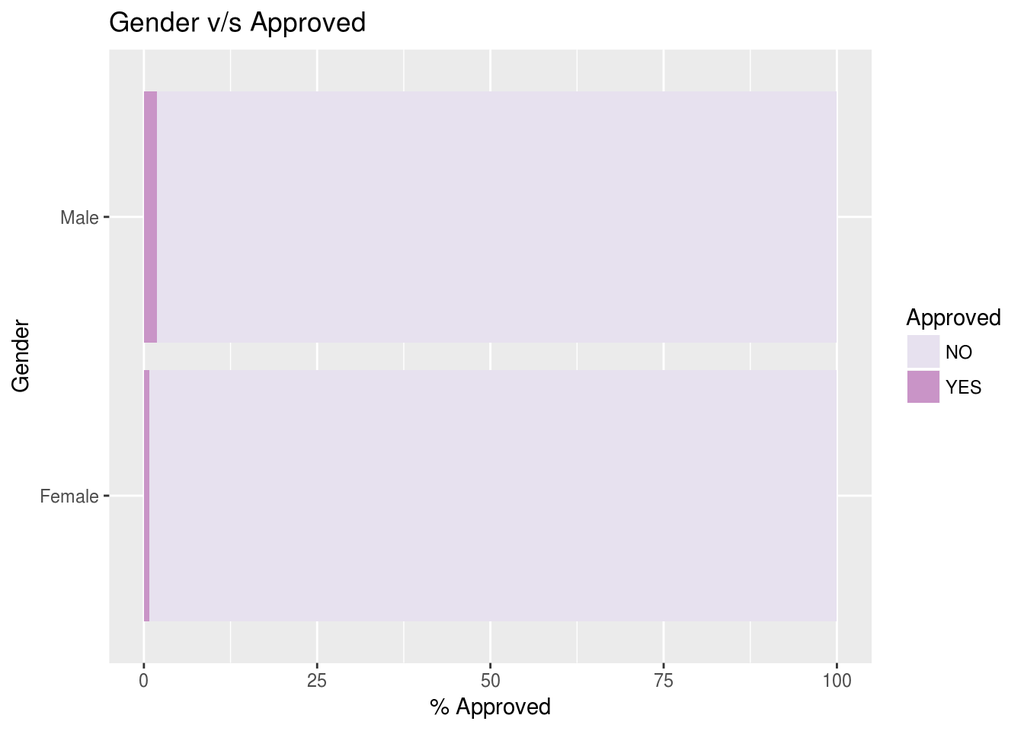

```r
trainData_WIP %>% group_by(Gender, Approved) %>%
  summarise(count=n()) %>%
  mutate(perc=count/sum(count)) %>%
  ggplot(aes(x=Gender, y=perc*100, fill=Approved)) +
  geom_bar(stat="identity") +
  geom_col(show.legend = T, ) +
  labs(title="Gender v/s Approved", y="% Approved") +
  scale_fill_brewer(palette="PuRd") +
  coord_flip()
```

```r
#Bivariate analysis: City_Category v/s Approved
chisq.test(trainData_WIP$City_Category, trainData_WIP$Approved)
```

```
##
##  Pearson's Chi-squared test
##
## data:  trainData_WIP$City_Category and trainData_WIP$Approved
## X-squared = 57.159, df = 3, p-value = 2.376e-12
```

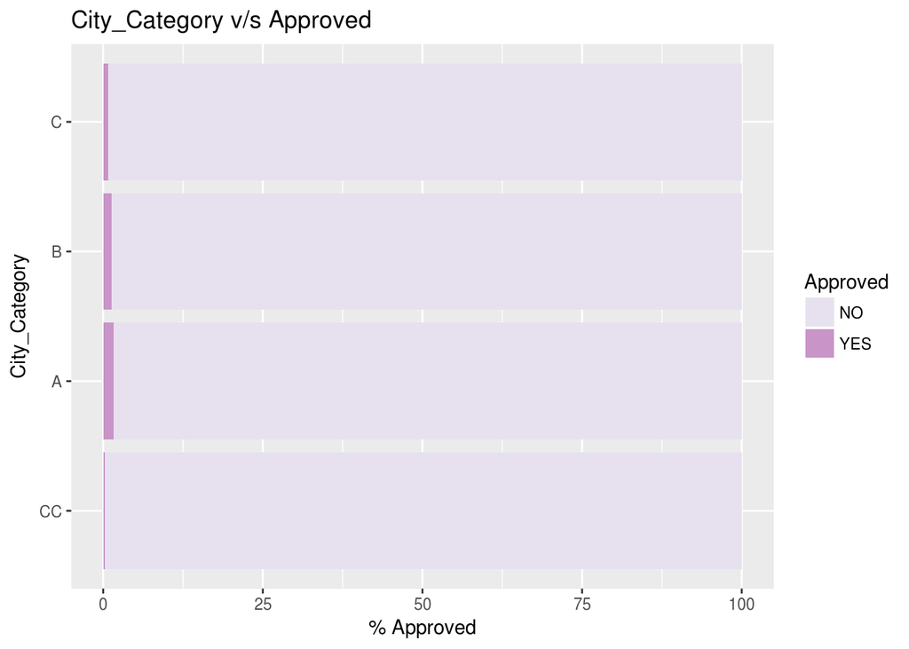

```r
trainData_WIP %>% group_by(City_Category, Approved) %>%
  summarise(count=n()) %>%
  mutate(perc=count/sum(count)) %>%
  ggplot(aes(x=City_Category, y=perc*100, fill=Approved)) +
  geom_bar(stat="identity") +
  geom_col(show.legend = T, ) +
  labs(title="City_Category v/s Approved", y="% Approved") +
  scale_fill_brewer(palette="PuRd") +
  coord_flip()
```

```r
#Bivariate analysis: Employer_Category1 v/s Approved
chisq.test(trainData_WIP$Employer_Category1, trainData_WIP$Approved)
```

```
##
##  Pearson's Chi-squared test
##
## data:  trainData_WIP$Employer_Category1 and trainData_WIP$Approved
## X-squared = 154.66, df = 3, p-value < 2.2e-16
```

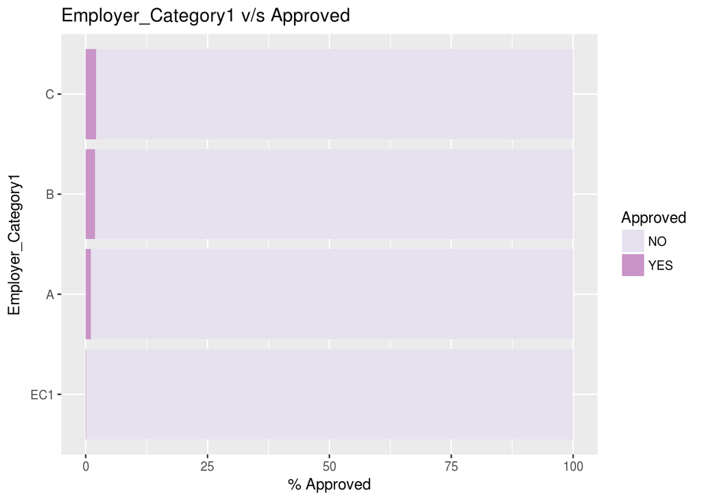

```r
trainData_WIP %>% group_by(Employer_Category1, Approved) %>%
  summarise(count=n()) %>%
  mutate(perc=count/sum(count)) %>%
  ggplot(aes(x=Employer_Category1, y=perc*100, fill=Approved)) +
  geom_bar(stat="identity") +
  geom_col(show.legend = T, ) +
  labs(title="Employer_Category1 v/s Approved", y="% Approved") +
  scale_fill_brewer(palette="PuRd") +
  coord_flip()
```

```r
#Bivariate analysis: Employer_Category2 v/s Approved
chisq.test(trainData_WIP$Employer_Category2, trainData_WIP$Approved)
```

```
##
##  Pearson's Chi-squared test
##
## data:  trainData_WIP$Employer_Category2 and trainData_WIP$Approved
## X-squared = 78.051, df = 4, p-value = 4.507e-16
```

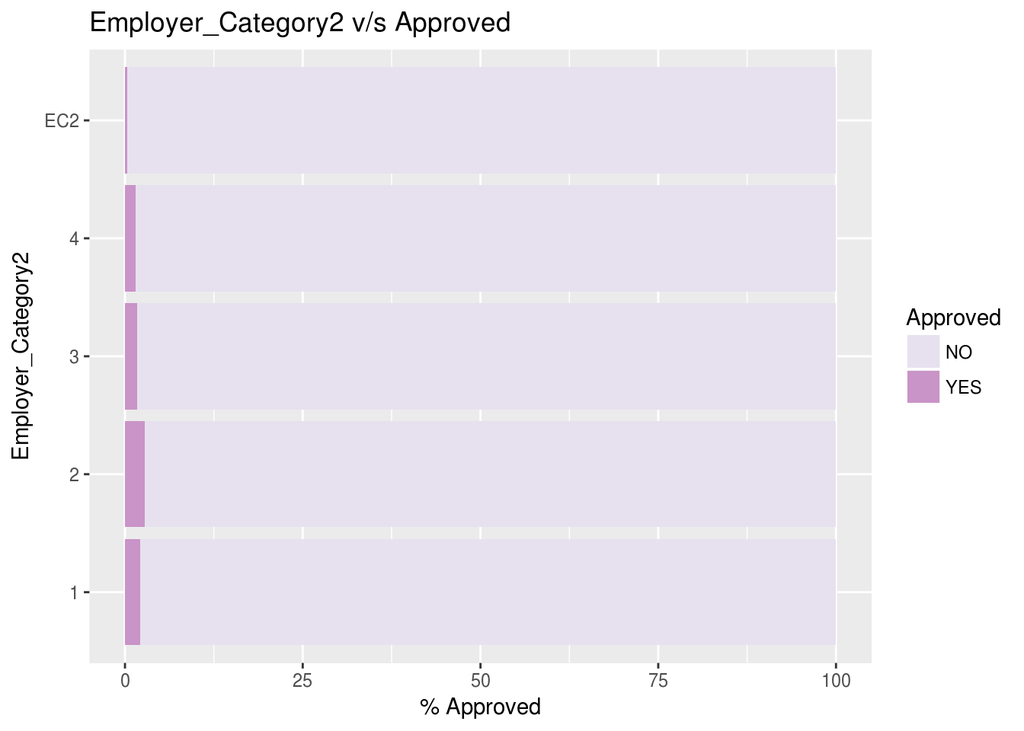

```r
trainData_WIP %>% group_by(Employer_Category2, Approved) %>%
  summarise(count=n()) %>%
  mutate(perc=count/sum(count)) %>%
  ggplot(aes(x=Employer_Category2, y=perc*100, fill=Approved)) +
  geom_bar(stat="identity") +
  geom_col(show.legend = T, ) +
  labs(title="Employer_Category2 v/s Approved", y="% Approved") +
  scale_fill_brewer(palette="PuRd") +
  coord_flip()
```

```r
#Bivariate analysis: Primary_Bank_Type v/s Approved
chisq.test(trainData_WIP$Primary_Bank_Type, trainData_WIP$Approved)
```

```
##
##  Pearson's Chi-squared test
##
## data:  trainData_WIP$Primary_Bank_Type and trainData_WIP$Approved
## X-squared = 228.98, df = 2, p-value < 2.2e-16
```

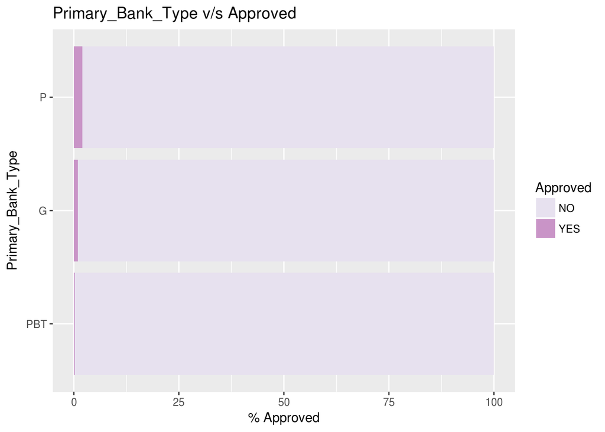

```r
trainData_WIP %>% group_by(Primary_Bank_Type, Approved) %>%
  summarise(count=n()) %>%
  mutate(perc=count/sum(count)) %>%
  ggplot(aes(x=Primary_Bank_Type, y=perc*100, fill=Approved)) +
  geom_bar(stat="identity") +
  geom_col(show.legend = T, ) +
  labs(title="Primary_Bank_Type v/s Approved", y="% Approved") +
  scale_fill_brewer(palette="PuRd") +
  coord_flip()
```

```r
#Bivariate analysis: Contacted v/s Approved
chisq.test(trainData_WIP$Contacted, trainData_WIP$Approved)
```

```
##
##  Pearson's Chi-squared test with Yates' continuity correction
##
## data:  trainData_WIP$Contacted and trainData_WIP$Approved
## X-squared = 147.62, df = 1, p-value < 2.2e-16
```

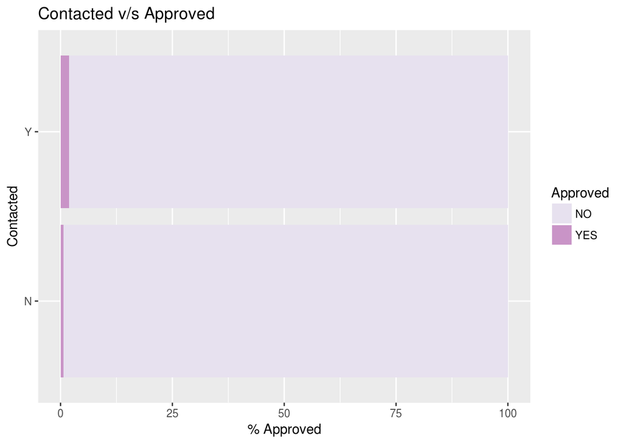

```r
trainData_WIP %>% group_by(Contacted, Approved) %>%
  summarise(count=n()) %>%
  mutate(perc=count/sum(count)) %>%
  ggplot(aes(x=Contacted, y=perc*100, fill=Approved)) +
  geom_bar(stat="identity") +
  geom_col(show.legend = T, ) +
  labs(title="Contacted v/s Approved", y="% Approved") +
  scale_fill_brewer(palette="PuRd") +
  coord_flip()
```

```r
#Bivariate analysis: Source_Category v/s Approved
chisq.test(trainData_WIP$Source_Category, trainData_WIP$Approved)
```

```
##
##  Pearson's Chi-squared test
##
## data:  trainData_WIP$Source_Category and trainData_WIP$Approved
## X-squared = 21.321, df = 6, p-value = 0.001606
```

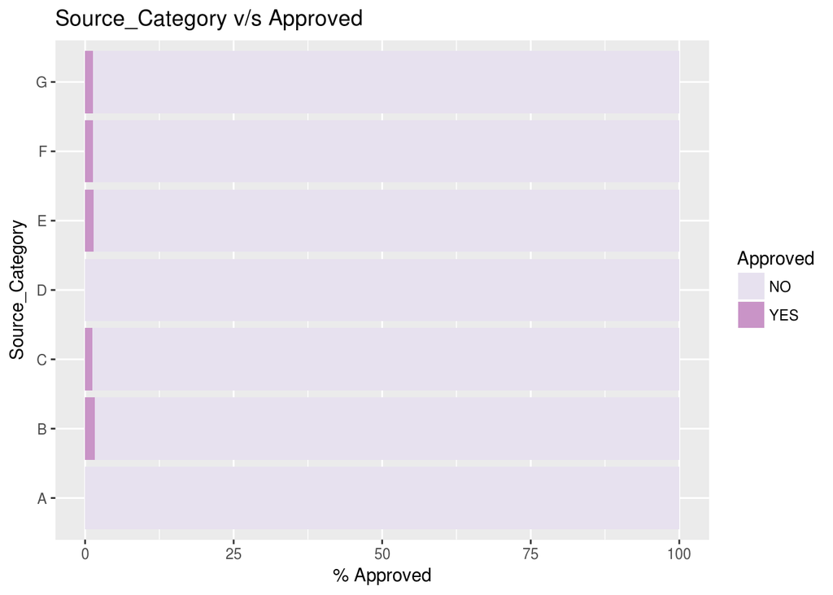

```r
trainData_WIP %>% group_by(Source_Category, Approved) %>%
  summarise(count=n()) %>%
  mutate(perc=count/sum(count)) %>%
  ggplot(aes(x=Source_Category, y=perc*100, fill=Approved)) +
  geom_bar(stat="identity") +
  geom_col(show.legend = T, ) +
  labs(title="Source_Category v/s Approved", y="% Approved") +
  scale_fill_brewer(palette="PuRd") +
  coord_flip()
```

```r
#Bivariate analysis: Var1 v/s Approved
chisq.test(trainData_WIP$Var1, trainData_WIP$Approved)
```

```
##
##  Pearson's Chi-squared test
##
## data:  trainData_WIP$Var1 and trainData_WIP$Approved
## X-squared = 1016.6, df = 4, p-value < 2.2e-16
```

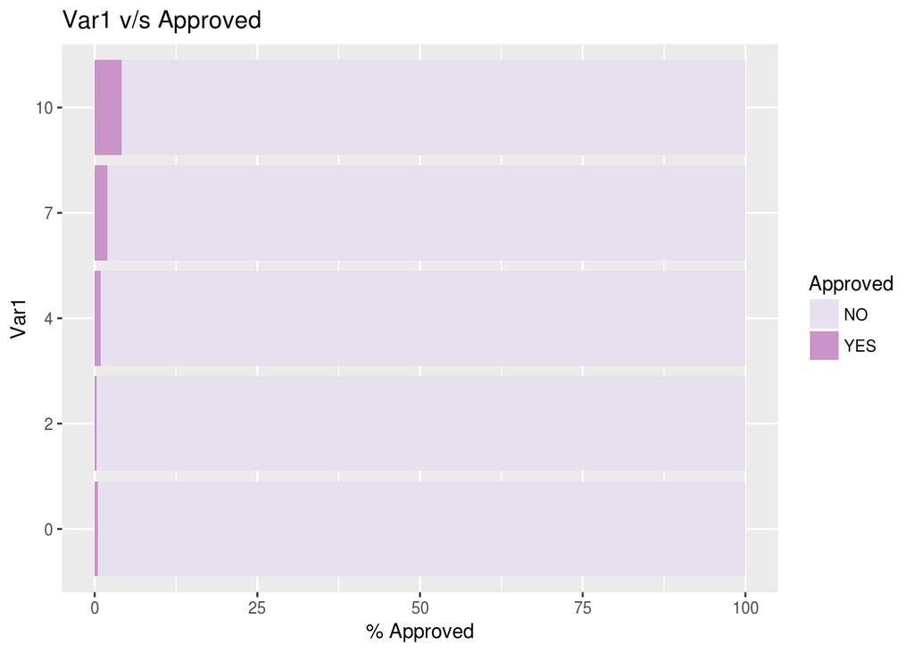

```r
trainData_WIP %>% group_by(Var1, Approved) %>%
  summarise(count=n()) %>%
  mutate(perc=count/sum(count)) %>%
  ggplot(aes(x=Var1, y=perc*100, fill=Approved)) +
  geom_bar(stat="identity") +
  geom_col(show.legend = T, ) +
  labs(title="Var1 v/s Approved", y="% Approved") +
  scale_fill_brewer(palette="PuRd") +
  coord_flip()
```

```r
summary(trainData_WIP)
```

```
##                ID           Gender      City_Category Employer_Category1
##  APPA10000905029:    1   Female:29738   CC:  814      EC1: 4003
##  APPA10001412205:    1   Male  :39909   A :49829      A  :33285
##  APPA10004965619:    1                  B : 7315      B  :18056
##  APPA10007179048:    1                  C :11689      C  :14303
##  APPA10007532038:    1
##  APPA10009948043:    1
##  (Other)        :69641
##  Employer_Category2 Primary_Bank_Type Contacted Source_Category Var1
##  1  : 4258          PBT: 9325         N:24414   A:    3         0 :23282
##  2  : 1955          G  :20703         Y:45233   B:29811         2 :13358
##  3  : 1620          P  :39619                   C:11374         4 : 7670
##  4  :57531                                      D:  496         7 :11935
##  EC2: 4283                                      E: 1050         10:13402
##                                                 F:  459
##                                                 G:26454
##  Approved    Monthly_Income_log Existing_EMI_log      Age
##  NO :68628   Min.   : 0.000     Min.   : 0.000   Min.   :18.00
##  YES: 1019   1st Qu.: 7.409     1st Qu.: 0.000   1st Qu.:27.00
##              Median : 7.824     Median : 0.000   Median :30.00
##              Mean   : 7.849     Mean   : 2.141   Mean   :31.83
##              3rd Qu.: 8.294     3rd Qu.: 5.861   3rd Qu.:35.00
##              Max.   :17.463     Max.   :13.209   Max.   :88.00
##
```

```r
str(trainData_WIP)
```

```
## 'data.frame':    69647 obs. of  13 variables:
##  $ ID                : Factor w/ 69713 levels "APPA10000905029",..: 7809 9062 12525 15528 17798 24053 28923 29974 33036 36522 ...
##  $ Gender            : Factor w/ 2 levels "Female","Male": 1 2 2 2 2 1 2 1 2 1 ...
##  $ City_Category     : Factor w/ 4 levels "CC","A","B","C": 2 2 4 4 2 4 3 2 2 3 ...
##  $ Employer_Category1: Factor w/ 4 levels "EC1","A","B",..: 2 4 4 2 2 2 3 2 2 2 ...
##  $ Employer_Category2: Factor w/ 5 levels "1","2","3","4",..: 4 1 4 4 4 4 4 4 4 4 ...
##  $ Primary_Bank_Type : Factor w/ 3 levels "PBT","G","P": 3 3 2 2 3 3 2 3 2 1 ...
##  $ Contacted         : Factor w/ 2 levels "N","Y": 1 2 2 2 2 1 2 2 2 1 ...
##  $ Source_Category   : Factor w/ 7 levels "A","B","C","D",..: 7 7 2 2 2 2 3 2 2 2 ...
##  $ Var1              : Factor w/ 5 levels "0","2","4","7",..: 1 5 1 4 5 1 5 1 4 1 ...
##  $ Approved          : Factor w/ 2 levels "NO","YES": 1 1 1 1 1 1 1 1 1 1 ...
##  $ Monthly_Income_log: num  7.6 8.16 7.72 8.16 9.21 ...
##  $ Existing_EMI_log  : num  0 0 0 0 7.82 ...
##  $ Age               : num  38 31 35 28 32 29 44 27 40 27 ...
```

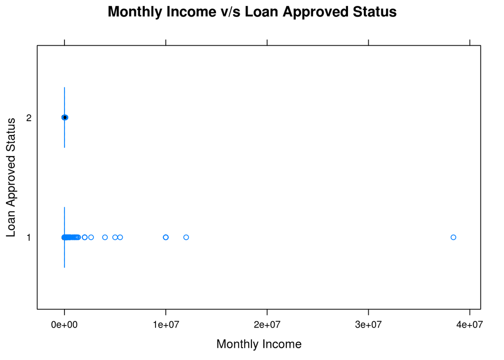

```r
bwplot(Approved~Monthly_Income, data = trainData, xlab = 'Monthly Income', ylab = 'Loan Approved Status', main = 'Monthly Income v/s Loan Approved Status')
```

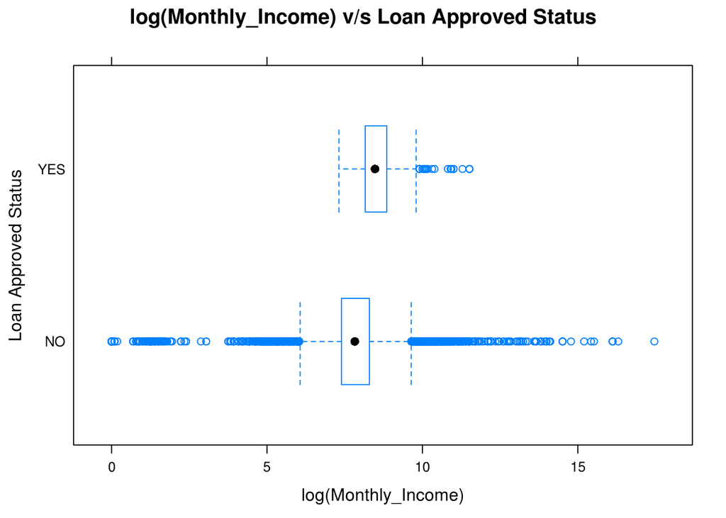

```r
bwplot(Approved~Monthly_Income_log, data = trainData_WIP, xlab = 'log(Monthly_Income)', ylab = 'Loan Approved Status', main = 'log(Monthly_Income) v/s Loan Approved Status')
```

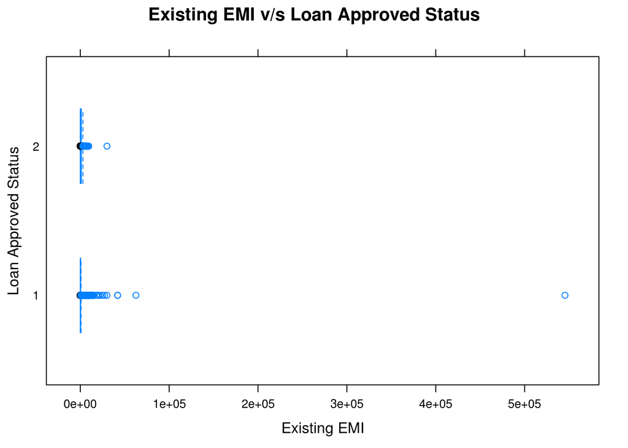

```r
bwplot(Approved~Existing_EMI, data = trainData, xlab = 'Existing EMI', ylab = 'Loan Approved Status', main = 'Existing EMI v/s Loan Approved Status')
```

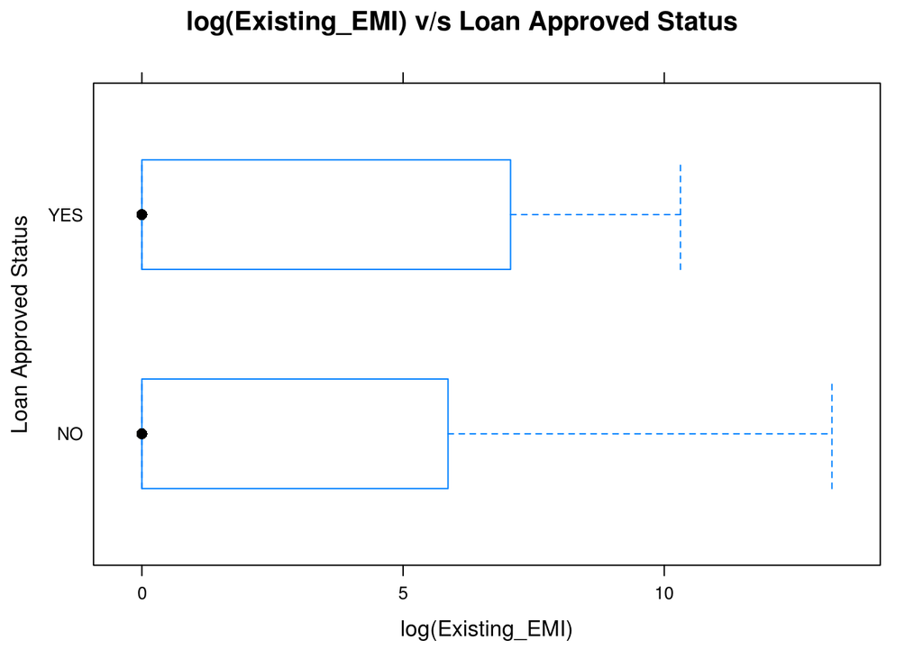

```r
bwplot(Approved~Existing_EMI_log, data = trainData_WIP, xlab = 'log(Existing_EMI)', ylab = 'Loan Approved Status', main = 'log(Existing_EMI) v/s Loan Approved Status')
```

## Model training and evaluation

From EDA, we see that of only 1,000 Approvals were given out of about 70,000 applicants. That’s 1.5%. This highly imbalanced dataset creates special problems for our analysis.  
Despite much optmization, the running time of the model training code below exceeds 8 hours each. Hence optimization has not been done and much scope remains to further optimize the dataset (like balancing data classes) and model training. The training and the performance of the two iterations (Random Forest and Gradient Boosted Model) executed are shown below.

```r
#check using RF model through caret
set.seed(605)
Control <- trainControl(
  #method = 'repeatedcv', number = 1, repeats = 3, #these values may have changed
                          classProbs = TRUE, summaryFunction = twoClassSummary)
modelRF <- train(Approved~., data = trainData_WIP[,-which(names(trainData_WIP) %in% c('ID'))],
                 method = 'rf', trControl = Control, metric = 'ROC')

#check using GBM model through caret
fitControl <- trainControl(
  #method = 'repeatedcv', number = 10, repeats = 10, #these values may have changed
                          classProbs = TRUE, summaryFunction = twoClassSummary)
set.seed(605)
modelGBM <- train(Approved~., data = trainData_WIP[,-which(names(trainData_WIP) %in% c('ID'))],
                  method = 'gbm', trControl = fitControl, metric = 'ROC', verbose = FALSE)
```

### Performance of the Random Forest model

```r
library(caret)
modelRF <-readRDS('modelRF.rds')
modelRF
```

```
## Random Forest
##
## 69647 samples
##    11 predictors
##     2 classes: 'NO', 'YES'
##
## No pre-processing
## Resampling: Bootstrapped (25 reps)
## Summary of sample sizes: 69647, 69647, 69647, 69647, 69647, 69647, ...
## Resampling results across tuning parameters:
##
##   mtry  ROC        Sens       Spec
##    2    0.5972774  1.0000000  0.000000000
##   14    0.7577146  0.9983608  0.006211022
##   27    0.7486804  0.9973298  0.008682156
##
## ROC was used to select the optimal model using  the largest value.
## The final value used for the model was mtry = 14.
```

```r
#varImp(modelRF, scale = FALSE)
```

### Performance of the Gradient Boosted Model

```r
library(caret)
modelGBM <- readRDS('modelGBM.rds')
modelGBM
```

```
## Stochastic Gradient Boosting
##
## 69647 samples
##    11 predictors
##     2 classes: 'NO', 'YES'
##
## No pre-processing
## Resampling: Bootstrapped (25 reps)
## Summary of sample sizes: 69647, 69647, 69647, 69647, 69647, 69647, ...
## Resampling results across tuning parameters:
##
##   interaction.depth  n.trees  ROC        Sens       Spec
##   1                   50      0.8152634  1.0000000  0
##   1                  100      0.8203908  1.0000000  0
##   1                  150      0.8220492  1.0000000  0
##   2                   50      0.8222038  0.9999984  0
##   2                  100      0.8247832  0.9999731  0
##   2                  150      0.8255135  0.9999699  0
##   3                   50      0.8235724  0.9999810  0
##   3                  100      0.8253865  0.9999366  0
##   3                  150      0.8255095  0.9999081  0
##
## Tuning parameter 'shrinkage' was held constant at a value of 0.1
##
## Tuning parameter 'n.minobsinnode' was held constant at a value of 10
## ROC was used to select the optimal model using  the largest value.
## The final values used for the model were n.trees = 150,
##  interaction.depth = 2, shrinkage = 0.1 and n.minobsinnode = 10.
```

```r
#varImp(modelGBM, scale = FALSE)
```

## Predictions

Code used to make and save predictions to submit to the hackathon.

```r
RF_results <- predict(modelRF, newdata = testData_WIP)
submission <- cbind(as.character(testData_WIP$ID), RF_results)
submission <- as.data.frame(submission)
names(submission) <- c('ID', 'Approved')
levels(submission$Approved)[levels(submission$Approved) == 1] <- 0
levels(submission$Approved)[levels(submission$Approved) == 2] <- 1
write.csv(submission, file='submission_RF.csv', row.names = FALSE)

#similarly for all other models, inc GBM
```

### Downsampling

A simple downsampling provided interesting insights and improvements. Although Sensitivity continues to be the metric of importance, Specifcity in this case is reasonable. Options to optimize further are listed in the Next Steps section below.

```r
#downsampling
trainDataTrimmed_small <- downSample(x=trainData_WIP[,-which(names(trainData_WIP) %in%
                                                                  c('ID', 'Approved'))],
                                    y=trainData_WIP$Approved)
Control <- trainControl(
  #method = 'repeatedcv', number = 10, repeats = 3,
  classProbs = TRUE, summaryFunction = twoClassSummary)
modelRF_downsample <- train(Class~., data = trainDataTrimmed_small[,-which(names(trainDataTrimmed) %in% c('ID'))],
                 method = 'rf', trControl = Control, metric = 'ROC')
```

### Performance of the down sampled Random Forest model

```r
modelRF_downsample <- readRDS('modelRF_downsample.rds')
modelRF_downsample
```

```
## Random Forest
##
## 2038 samples
##   10 predictors
##    2 classes: 'NO', 'YES'
##
## No pre-processing
## Resampling: Bootstrapped (25 reps)
## Summary of sample sizes: 2038, 2038, 2038, 2038, 2038, 2038, ...
## Resampling results across tuning parameters:
##
##   mtry  ROC        Sens       Spec
##    2    0.8115908  0.6624822  0.8292545
##   14    0.8012812  0.6807862  0.7632322
##   26    0.7947379  0.6760104  0.7571882
##
## ROC was used to select the optimal model using  the largest value.
## The final value used for the model was mtry = 2.
```

```r
varImp(modelRF_downsample, scale = FALSE)
```

```
## rf variable importance
##
##   only 20 most important variables shown (out of 26)
##
##                       Overall
## Monthly_Income_log    120.190
## Var110                 41.426
## Age                    37.065
## Existing_EMI_log       35.602
## Var12                  21.047
## Primary_Bank_TypeP     19.296
## ContactedY             15.139
## Var17                  11.067
## Employer_Category1A     7.812
## Primary_Bank_TypeG      6.873
## Employer_Category2EC2   6.602
## Employer_Category1C     6.226
## Employer_Category1B     5.609
## Var14                   4.887
## City_CategoryC          4.799
## Employer_Category24     4.798
## Source_CategoryB        4.740
## Source_CategoryG        4.738
## City_CategoryA          4.622
## Source_CategoryC        3.709
```

## Next steps

There are several avenues to pursue this further, including,  
The output of variable importance of the downsampled RF model could be used to trim columns from the dataset and then run training on all the records.  
The reason for the very slow model training seems to be the large number of classes (e.g. ‘Source’ = 29 levels, ‘Customer_Existing_Primary_Bank_Code’ = 58 levels, and even larger numbers for City and Employer). Many of these are imbalanced as well. Instead ofexcluding from the model, can the classes be combined?  
Instead of a 1:1 downsampling that cuts the dataset size to about 2,000, can the frequent class (loan denied) be downsampled to about 10,000 records?

## Using functions

To maintain high reuse and repeatability, data pre-processing/ munging has been placed into functions.

```r
McK_pre_proc_train_only <- function (McKSalesData) {
  McKSalesDataTrimmed <- McKSalesData[complete.cases(McKSalesData[,'Existing_EMI']),]# dropping NA rows
  McKSalesDataTrimmed <- McKSalesDataTrimmed[!(McKSalesDataTrimmed$DOB == ''),]
  change_to_fact <- c('Approved')
  McKSalesDataTrimmed[change_to_fact] <- lapply(McKSalesDataTrimmed[change_to_fact], factor)#converting above columns to categorical
  levels(McKSalesDataTrimmed$Approved)[levels(McKSalesDataTrimmed$Approved) == '0'] <- 'NO'
  levels(McKSalesDataTrimmed$Approved)[levels(McKSalesDataTrimmed$Approved) == '1'] <- 'YES'
  McKSalesDataTrimmed
}

McK_pre_proc_test_only <- function (McKSalesData) {
  McKSalesData$Existing_EMI[is.na(McKSalesData$Existing_EMI)] <- 1 ## dummy value for NA rows in test data
  levels(McKSalesData$DOB)[levels(McKSalesData$DOB) == ''] <- '01/01/2000' ## dummy value for blank rows in test data
  McKSalesData
}

calc_age <- function(birthDate, refDate = Sys.Date()) {           #function that calculates years since a given date
                                                                  #to current/ system date (reused code found on github)
  require(lubridate)
  period <- as.period(interval(birthDate, refDate), unit = "year")
  period$year
}

McK_pre_proc_common <- function (McKSalesData) {
  #dropping less informative columns
  drops <- c('EMI', 'Interest_Rate', 'Loan_Period', 'Loan_Amount', "Lead_Age", 'Employer_Code', 'City_Code',
             'Lead_Creation_Date', 'Customer_Existing_Primary_Bank_Code', 'Source') #picking less informative columns
  McKSalesDataTrimmed <- McKSalesData[,!names(McKSalesData) %in% drops] #dropping above columns
  McKSalesDataTrimmed$Employer_Category2[is.na(McKSalesDataTrimmed$Employer_Category2)] <- 'EC2' #fixing NA in a variable before making it categorical
  #converting these columns to categorical
  change_to_fact <- c('Var1', 'Employer_Category2')
  McKSalesDataTrimmed[change_to_fact] <- lapply(McKSalesDataTrimmed[change_to_fact], factor)
  #Unlabelled levels fix
  levels(McKSalesDataTrimmed$Primary_Bank_Type)[levels(McKSalesDataTrimmed$Primary_Bank_Type) == ''] <- 'PBT'
  levels(McKSalesDataTrimmed$Employer_Category1)[levels(McKSalesDataTrimmed$Employer_Category1) == ''] <- 'EC1'
  levels(McKSalesDataTrimmed$City_Category)[levels(McKSalesDataTrimmed$City_Category) == ''] <- 'CC'
  #transforming continous variables (other transformations like upper bound, exp and sqrt tested and rejected)
  #the +1 is because of zeros in the data and we need to prevent the invalid log of zero calculation
  McKSalesDataTrimmed$Monthly_Income_log <- log(McKSalesDataTrimmed$Monthly_Income+1)
  McKSalesDataTrimmed$Existing_EMI_log <- log(McKSalesDataTrimmed$Existing_EMI+1)
  drops_trfm <- c('Existing_EMI', 'Monthly_Income')
  McKSalesDataTrimmed <- McKSalesDataTrimmed[,!names(McKSalesDataTrimmed) %in% drops_trfm] #dropping the original/ untransformed columns
  #transforming the 'DOB' continous variable to 'Age'. Several ages are negative (POSIX standards issue with converting yy to YYYY format) and need to be fixed.
  McKSalesDataTrimmed$Age <- calc_age(as.Date(McKSalesDataTrimmed$DOB, format = '%d/%m/%y'))
  neg_age_index <- as.Date(McKSalesDataTrimmed$DOB, format = '%d/%m/%y') > Sys.Date()
  McKSalesDataTrimmed$Age[neg_age_index] <- McKSalesDataTrimmed$Age[neg_age_index]+100
  McKSalesDataTrimmed <- McKSalesDataTrimmed[,!names(McKSalesDataTrimmed) %in% c("DOB")] #dropping DOB columns
  McKSalesDataTrimmed
}
```